# Analysis of SARS-CoV-2 concentration in wastewater

Julia Wrobel

2024-07-23

## Overview

This file produces a report of the wastewater concentration of SARS-CoV-2 in different counties in NC. Data for this report was downloaded from the CDC website on 2024-07-23.

## Download and clean data

Two data sources were pulled and merged for this analysis. One is a dataset of SARS-CoV-2 wastewater concentration at different sampling sites, which can be accessed [here](https://data.cdc.gov/Public-Health-Surveillance/NWSS-Public-SARS-CoV-2-Concentration-in-Wastewater/g653-rqe2/about_data). The second, accessible [here](https://data.cdc.gov/Public-Health-Surveillance/NWSS-Public-SARS-CoV-2-Wastewater-Metric-Data/2ew6-ywp6/about_data), contains summary information about SARS-CoV-2 wastewater concentration at different sites, with additional information about site location including county and state.

First we downloaded and cleaned the data from the CDC website.

```r
if(params$download_raw_data){
  source(here("source", "01_data_download.R"))
}else if(!file.exists(here::here("data", "raw.Rdata"))){
  source(here("source", "01_data_download.R"))
}

source(here("source", "02_data_cleaning.R"))
```

## Analysis

Next we did a simple analysis of the concentrations across different counties in NC. Specifically, we calculated the median and interquartile range within each county, which are given in the table below:

```r
source(here("source", "03_data_analysis.R"))
```

```r
covid_table %>%
  knitr::kable()
```

| county | median | q25 | q75 | population_served |
| --- | --- | --- | --- | --- |
| Wilson | 2.040000e-04 | 8.740000e-05 | 4.694000e-04 | 50000 |
| Forsyth | 2.310000e-04 | 9.680000e-05 | 6.328000e-04 | 92000 |
| Lenoir | 1.098700e-03 | 3.059000e-04 | 5.173600e-03 | 25000 |
| Jackson | 7.408257e+05 | 5.913577e+05 | 1.643449e+06 | 13296 |
| Henderson | 2.005935e+06 | 1.404020e+06 | 4.778317e+06 | 43633 |
| Scotland | 2.125908e+06 | 9.199582e+05 | 4.504154e+06 | 15527 |
| Mcdowell | 2.959382e+06 | 1.917805e+06 | 4.215519e+06 | 8459 |
| Cumberland | 5.552356e+06 | 3.810667e+06 | 1.144244e+07 | 151589 |
| Swain,Jackson | 7.602051e+06 | 4.229898e+06 | 1.570540e+07 | 10000 |
| Onslow | 8.689769e+06 | 2.881140e+06 | 1.650361e+07 | 41819 |
| Forsyth,Guilford,Randolph,Davidson | 1.008012e+07 | 7.140224e+06 | 1.321885e+07 | 116390 |
| Guilford | 1.090030e+07 | 8.839001e+06 | 3.490667e+07 | 135821 |
| Buncombe,Henderson | 1.175001e+07 | 7.649537e+06 | 1.747378e+07 | 173000 |
| Pitt | 1.396276e+07 | 8.261893e+06 | 3.036220e+07 | 89616 |
| New Hanover | 1.444451e+07 | 9.629462e+06 | 2.947398e+07 | 63052 |
| Durham | 1.490688e+07 | 1.042496e+07 | 2.663281e+07 | 142000 |
| Carteret | 1.616966e+07 | 8.822835e+06 | 4.519737e+07 | 3500 |
| Durham,Orange | 1.626229e+07 | 1.283364e+07 | 2.917262e+07 | 78141 |
| Rowan | 1.638796e+07 | 7.967937e+06 | 3.278875e+07 | 26500 |
| Pender,Duplin | 1.686007e+07 | 7.268376e+06 | 3.781589e+07 | 10000 |
| Northampton,Halifax | 1.941076e+07 | 9.920344e+06 | 2.499575e+07 | 14320 |
| Watauga | 2.174160e+07 | 1.057072e+07 | 3.986654e+07 | 26000 |
| Mecklenburg | 2.306376e+07 | 1.692153e+07 | 5.009678e+07 | 120000 |
| Wake | 2.873827e+07 | 1.667740e+07 | 4.945437e+07 | 75886 |

## Visualization

Finally, we visualize the concentration across counties.

```r
source(here("source", "04_data_visualization.R"))
```

First we look at boxplots of the `log(concentration)` of SARS-CoV-2 across counties in NC. The counties have been shorted from lowest to highest SARS-CoV-2 concentration.

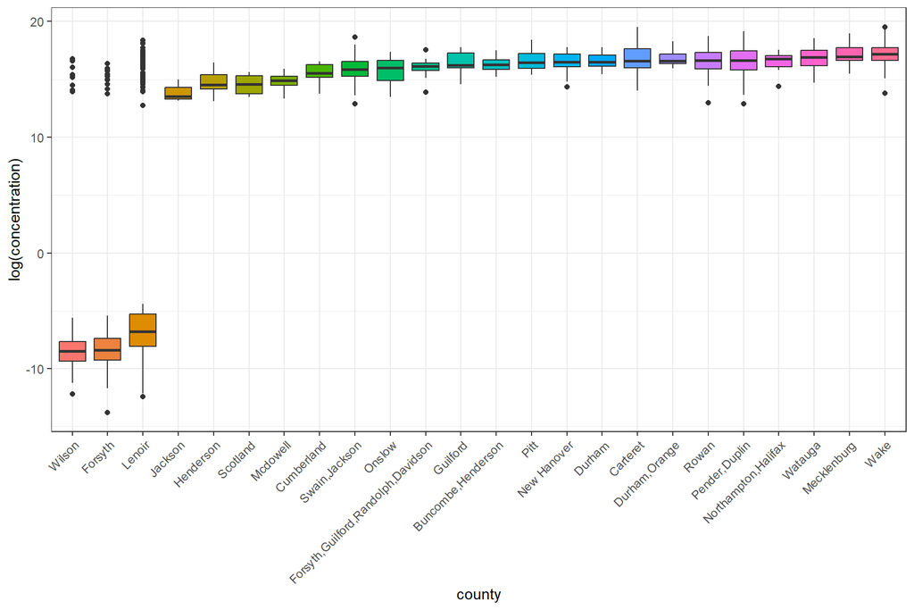

```r
plot1
```

Next, we visualize trends in SARS-CoV-2 concentration over time.

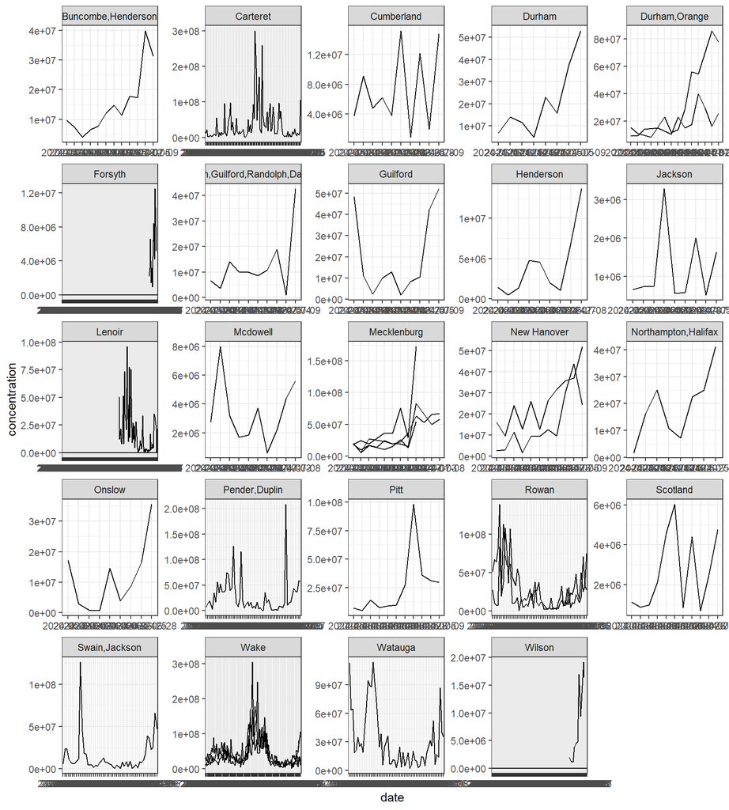

```r
plot2
```